# test

```python
import pandas as pd
import numpy as np
import matplotlib.pyplot as pplt
from dateutil import parser
import seaborn as sns
from sklearn.decomposition import PCA
from scipy import interpolate
import pickle
import os
import itertools
from joblib import Parallel, delayed
import random
```

```python
pd.set_option('display.float_format', lambda x: '%.5f' % x)
```

```python
parse_dates = ['registration', 'last_login']
df_raw = pd.read_csv("profiles.csv", parse_dates=parse_dates)
df_raw.head()
```

|  | user_id | public | gender | last_login | registration | AGE | height | weight |
| --- | --- | --- | --- | --- | --- | --- | --- | --- |
| 0 | 135772620 | True | 1.00000 | 2015-09-03 14:31:00 | 2010-02-25 | 23.00000 | 187.00000 | 80.00000 |
| 1 | 317590764 | True | 1.00000 | 2015-10-14 00:45:00 | 2010-01-23 | 18.00000 | 182.00000 | 80.00000 |
| 2 | 862145884 | True | 0.00000 | 2015-01-05 17:48:00 | 2010-04-10 | 0.00000 | NaN | NaN |
| 3 | 143472163 | True | 0.00000 | 2015-10-13 23:28:00 | 2015-02-11 | 33.00000 | 184.00000 | NaN |
| 4 | 16152737 | True | 1.00000 | 2015-10-01 18:38:00 | 2008-08-27 | NaN | NaN | NaN |

```python
relation = pd.read_csv("relationships.csv")
relation.head()
```

|  | user_id | friend_id |
| --- | --- | --- |
| 0 | 170252712 | 882458036 |
| 1 | 248253060 | 533862043 |
| 2 | 269388032 | 570362114 |
| 3 | 573277274 | 925016869 |
| 4 | 898111134 | 514413545 |

```python
test_users = pd.read_csv("test_users.txt", header=None, names=["id"])
test_users.tail()
```

|  | id |
| --- | --- |
| 27754 | 123901073 |
| 27755 | 352601406 |
| 27756 | 120883808 |
| 27757 | 435541900 |
| 27758 | 530536337 |

```python
df_raw.describe()
```

|  | user_id | gender | AGE | height | weight |
| --- | --- | --- | --- | --- | --- |
| count | 1632803.00000 | 1632640.00000 | 1604881.00000 | 729751.00000 | 620836.00000 |
| mean | 499997105.69006 | 0.49266 | 16.98046 | 808067266117481.62500 | 558154134404521408.00000 |
| std | 288699233.54438 | 0.49995 | 13.96685 | 85770960861341856.00000 | 438896788516499685376.00000 |
| min | 143.00000 | 0.00000 | 0.00000 | 0.00000 | 0.00000 |
| 25% | 249802760.00000 | 0.00000 | 0.00000 | 165.00000 | 52.00000 |
| 50% | 499910023.00000 | 0.00000 | 19.00000 | 172.00000 | 63.00000 |
| 75% | 749867091.00000 | 1.00000 | 26.00000 | 180.00000 | 77.00000 |
| max | 999999937.00000 | 1.00000 | 112.00000 | 9223372036854775808.00000 | 345820583218456029036544.00000 |

```python
df = df_raw.copy()
```

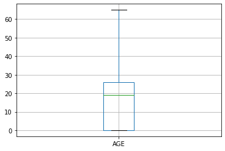

```python
df.boxplot("AGE", showfliers=False)
pplt.show()
```

## Prepare data

##### We won't use infrormation about date of registration or last login? so we can remove it

```python
df.drop(columns=['last_login', 'registration'], inplace=True)
```

##### A person can weight somewhere from 2kg to 700kg and have height from 40cm to 270cm.

Others have obviously lied:

```python
len(df[(df.weight < 2) | (df.weight > 700)])
```

```
2863
```

```python
len(df[(df.height < 40) | (df.height > 270)])
```

```
8001
```

##### We will remove these data about these people

```python
df["weight"] = df["weight"].map(lambda x: np.nan if x < 2 or x > 700 else x)
df["height"] = df["height"].map(lambda x: np.nan if x < 40 or x > 270 else x)
df["AGE"] = df["AGE"].map(lambda x: np.nan if x == 0 else x)
df["public"] = df["public"].map(lambda x: 1 if x else 0)
```

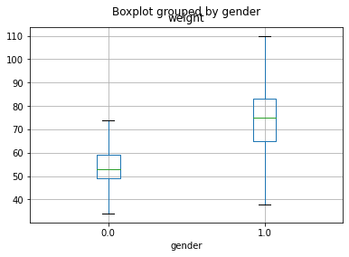

```python
df.boxplot("weight", by="gender", showfliers=False)
pplt.show()
```

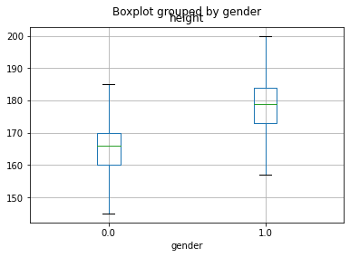

```python
df.boxplot("height", by="gender", showfliers=False)
pplt.show()
```

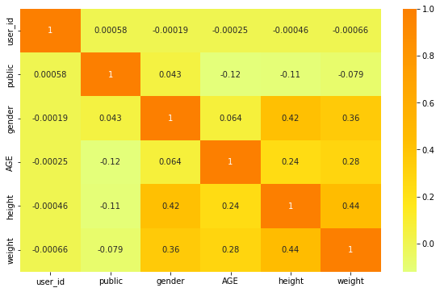

```python
corr = df.corr()
pplt.figure(figsize=(10, 6))
sns.heatmap(corr, cmap = 'Wistia', annot= True);
```

#### Let's get train set (users whose age is known). As we can see from the plot and plots above height, weight and gender are correlated.

```python
train_df = df.drop(df[df['AGE'].isna()].index)
```

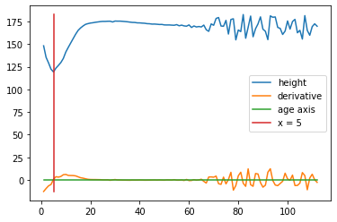

```
Age at which height is stabilizes: 25
```

```python
def plot_field_and_deviation(field):
    plot_df = train_df.groupby(["AGE"])[field].mean()

    age = plot_df.index
    field_value = list(plot_df)

    # Let's calculate derivative from field value
    tang = np.gradient(field_value, age)

    pplt.plot(age, field_value, label=field)
    pplt.plot(age, tang, label="derivative")

    # Plot age axis
    pplt.plot([age[0], age[-1]], [0, 0], linestyle='-', label="age axis")

    # Cut off strange values in the begining which has negative derivative
    ind_dev_posit = [i for i in range(len(tang)) if tang[i] > 2][0]
    pplt.plot([ind_dev_posit, ind_dev_posit], [min(tang), max(field_value)], linestyle='-', label=f'x = {ind_dev_posit}')

    pplt.legend()
    pplt.show()

    # At what age field value is stabilizes, but we should
    eps = 0.1
    ind_dev_zero = [i for i in range(len(tang)) if abs(tang[i]) < eps and i > ind_dev_posit][0]
    print(f"Age at which {field} is stabilizes: {ind_dev_zero}")

plot_field_and_deviation('height')
```

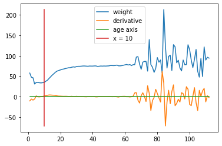

```
Age at which weight is stabilizes: 27
```

```python
plot_field_and_deviation('weight')
```

##### Height and weight are changing for people whose age is between 10 and 25. Let's add column with dummy variable which will be equal to 1 if age more than 10 and less than 25. For all others we will weight and height we will change to zero.

```python
train_df["teenager"] = train_df["AGE"].map(lambda x: 1 if x >= 10 and x <= 25 else 0)

train_df.loc[(train_df['AGE'] < 10), ['weight', 'height']] = 0
train_df.loc[(train_df['AGE'] > 25), ['weight', 'height']] = 0
```

##### There are nan values for teenagers. Let's feel them in.

```python
teenagers = train_df[train_df['teenager'] == 1]
group_by = teenagers.groupby(["AGE", "gender"])

fill_fields = ['height', 'weight']
train_df.loc[teenagers.index, fill_fields] = group_by[fill_fields].transform(lambda x: x.fillna(x.mean()))
```

```python
test_df = df[df.user_id.isin(test_users.id)]
test_df.reset_index(drop=True, inplace=True)
test_df['AGE'].unique()
```

```
array([nan])
```

##### Let's implement an algorithm described in article "A study of age gaps between online friends".

https://ink.library.smu.edu.sg/sis_research/2416/  
LIAO, Lizi; JIANG, Jing; LIM, Ee Peng; and HUANG, Heyan. A study of age gaps between online friends. HT'14: Proceedings of the 25th ACM Conference on Hypertext and Social Media: September 1-4, 2014, Santiago, Chile. 98-106. Research Collection School Of Information Systems.

```python
test_df = test_df[["user_id", "AGE"]]
train_df = train_df[["user_id", "AGE"]]
df = df[["user_id", "AGE"]]
```

```python
def get_users_friends_graph(user_id) -> list:
    """Get user's friends and friends' friends
    :param user_id: whose friends to look for
    """

    users = [user_id]
    add_users = [user_id]

    for _ in range(2):
        add_users = Parallel(n_jobs=10)(delayed(N)(add_user, exclude_ids=users) for add_user in add_users)
        add_users = set(sum(add_users, []))

        if len(add_users) > 1000:
            add_users = random.sample(add_users, 1000)
        users = list(users) + list(add_users)
    return users


def N(user_id, exclude_ids=[], include_ids=[]):
    """Get users unlabeled friends
    :param user_id: user_id
    :param exclude_ids: users who are already labeled
    :return: list of friends ids that are not labeled
    """
    global relation, neighbors

    if user_id in neighbors:
        users_friends = neighbors.get(user_id)

    else:
        users_friends = list(relation[relation["user_id"] == user_id].friend_id)
        users_friends += list(relation[relation["friend_id"] == user_id].user_id)

        # Save all users friends
        neighbors[user_id] = users_friends

    if len(exclude_ids) != 0:
        users_friends = [friend for friend in users_friends if friend not in exclude_ids]

    if len(include_ids) != 0:
        users_friends = [friend for friend in users_friends if friend in include_ids]

    return users_friends
```

```python
# Keep information about user neighbors
neighbors = {}
test_id = test_users.id[0]
users_friends = get_users_friends_graph(test_id)
```

In order to divide on cliques we need to get only first few friends. Plus if there is a unlabeled person above them we can label him to. But if we could not label person on first iteration he is likely to be near edge.

```python
def bronKerbosch(R=[], P=[], X=[], include_ids=[]):
    """Bron–Kerbosch algorithm with pivoting
    :return: list of cliques
    """
    if not P and not X:
        return [R]

    u = (P + X)[0]
    vertices = [vert for vert in P if vert not in N(u, include_ids=include_ids)]

    result = []
    for v in vertices:
        N_v = N(v, include_ids=include_ids)

        P_new = list(set(P) & set(N_v))
        X_new = list(set(X) & set(N_v))

        output = bronKerbosch(R + [v], P_new, X_new, include_ids)
        result.extend(output)

        P = [vert for vert in P if vert is not v]
        X = X + [v]
    return result


def count_probabilities(user_ids: list):
    """Divide graph on cliques and set probabilities for each edge
    :param user_ids: users that denote vertices
    :return: probab_values probabilities for each edge in friendship graph
    """

    probab_values = {i: {} for i in user_ids}

    # Divide graph on cliques
    for clique in bronKerbosch(P=user_ids, include_ids=user_ids):
        probab_values = update_edges(clique, probab_values)

    return probab_values


def update_edges(clique, probab_values):
    """update probability on edge if needed (select with max prob)
    :param clique: list of ids that make one clique
    :param probab_values: probabilities for each edge
    :return: probab_values probabilities for each edge in friendship graph
    """
    clique_size = len(clique)
    pairs = list(itertools.combinations(clique, 2))

    for i, j in pairs:
        edge_prob = probab_values.get(i, {}).get(j, 0)

        # compare clique_size with other cliques that contains i and j vertecies
        if clique_size <= edge_prob:
            continue

        probab_values[i][j] = clique_size
        probab_values[j][i] = clique_size
    return probab_values


def fill_age_probabilities(user_id, U, L, A, probab_values):
    """In order to propogate age labels fill age probobilities for each unlabeled vertex
    :param user_id: user whose label is not known
    :param U: users whose labels are not known
    :param L: users whose labels are known
    :param A: age probobilities for each vertex
    :param probab_values: probabilities for each edge
    :return: age probobilities for each vertex
    """

    # Get unlabeled friends ids
    user_neib = N(user_id, include_ids=list(U.user_id))

    # Count probability denominator
    prob_user = probab_values.get(user_id, {})

    # Get sum of labeled user's friend probobilities
    prob_divide = sum(prob_user.values())

    user_age = L.loc[L.user_id == user_id, "AGE"].iloc[0]

    if np.isnan(user_age):
        return A

    for neib_id in user_neib:
        prob = prob_user.get(neib_id)/prob_divide
        A[neib_id].append((user_age, prob))
    return A


def MCAP_alg(L, test_df):
    """Apply MCAP algorithm
    :param L: dataframe of users info - users whose age we know
    :param test_df: one user whose age need to be found
    :return: dataframe with labeled data
    """
    result = pd.DataFrame(columns=L.columns)

    test_id = test_df.user_id[0]

    #We will collect unnormolized probabilities and save them to file
    file_name = f"probabilities/{test_id}.pkl"
    user_ids = list(L.user_id) + list(test_df.user_id)

    if os.path.isfile(file_name):
        with open(file_name, 'rb') as handle:
            probab_values = pickle.load(handle)

    else:
        probab_values = count_probabilities(user_ids)
        with open(file_name, 'wb') as handle:
            pickle.dump(probab_values, handle, protocol=pickle.HIGHEST_PROTOCOL)

    A = {i: [] for i in user_ids}

    # To each neighbour in L add age and probability to A
    friends_to_fill_prob = []
    for i in list(test_df.user_id):
        friends_to_fill_prob.extend(N(i, include_ids=list(L.user_id)))

    for user_id in friends_to_fill_prob:
        A = fill_age_probabilities(user_id, test_df, L, A, probab_values)

    for user_id in test_df.user_id:
        if len(A[user_id]) == 0:
            continue

        user_info = test_df[test_df.user_id == user_id]
        # Label users with most probable age
        user_info['AGE'] = max(A[user_id], key=lambda item:item[1])[0]

        test_df.drop(test_df[test_df.user_id == user_id].index, inplace=True)
        result = result.append(user_info, ignore_index=True)
        L = L.append(user_info, ignore_index=True)

    return result
```

##### Even if friend is unlabeled we will at least know that he is there and it will influence learning (while normalizing weights - prob_divide)

```python
friends_df = df[df.user_id.isin(users_friends)]
test_user_df = test_df[test_df.user_id.isin(users_friends)].reset_index(drop=True)
test_user_info = MCAP_alg(friends_df, test_user_df)

test_user_info
```

|  | user_id | AGE |
| --- | --- | --- |
| 0 | 123937176 | 15.00000 |
| 1 | 481217157 | 33.00000 |
| 2 | 669408781 | 15.00000 |
| 3 | 183582290 | 15.00000 |
| 4 | 503723200 | 22.00000 |
| 5 | 986072016 | 12.00000 |
| 6 | 263435000 | 17.00000 |
| 7 | 32912118 | 13.00000 |
| 8 | 104292370 | 13.00000 |
| 9 | 512829981 | 11.00000 |
| 10 | 803031126 | 21.00000 |
| 11 | 421879788 | 24.00000 |
| 12 | 508451136 | 19.00000 |
| 13 | 354751790 | 10.00000 |
| 14 | 199007407 | 15.00000 |
| 15 | 543696290 | 11.00000 |
| 16 | 480889152 | 11.00000 |

```python
result = pd.DataFrame(columns=df.columns)
result = result.append(test_user_info, ignore_index=True)
# result.to_csv("result.csv", index=False)
```

```python
def apply_alg(test_id, test_df, df):
    result = pd.read_csv("result.csv", header=0)
    if test_id in list(result.user_id):
        print('Already calculated')
        return

    users_friends = get_users_friends_graph(test_id)

    friends_df = df[df.user_id.isin(users_friends)]

    test_user_df = test_df[test_df.user_id == test_id].reset_index(drop=True)

    test_user_info = MCAP_alg(friends_df, test_user_df)
    pd.DataFrame(test_user_info).to_csv("result.csv", mode='a', header=False, index=False)
    print('Calculated')

result = pd.read_csv("result.csv", header=0)
check = set(test_df.user_id) - set(result.user_id)
result_2 = Parallel(n_jobs=10)(delayed(apply_alg)(test_id, test_df, df) for test_id in check)
```

```python
result = pd.read_csv("result.csv", header=0)
result.drop_duplicates(subset='user_id', keep='last', inplace=True)
result.to_csv("result.csv", index=False)
```

Additionaly weights can be constructed using information about weight, height and gender. They are correlated so principal component analysis should be first applied. Coefficients before weight, height and gender can be found with linear regression.

But weight, height and gender should be used only for users whose age is in [15;25]